# 常用统计检验方法总结

### 案例3. 非参数检验

当数据不满足正态性、方差齐次性，并且想做单因素组间比较时，可使用非参数检验方法

这里主要指Kruskal-Wallis检验，可检验多个（≥2）独立样本：是否来自相同的总体，或者说这些样本在中位数或总体位置上是否相同。由于该方法是非参数检验，不要求正态性和方差齐次性，因此在这些情况下，可以作为单因素ANOVA的替代。

R语言中，使用`stats::kruskal.test`函数执行Kruskal-Wallis检验，其H0为各组分布（中位数）全相同。

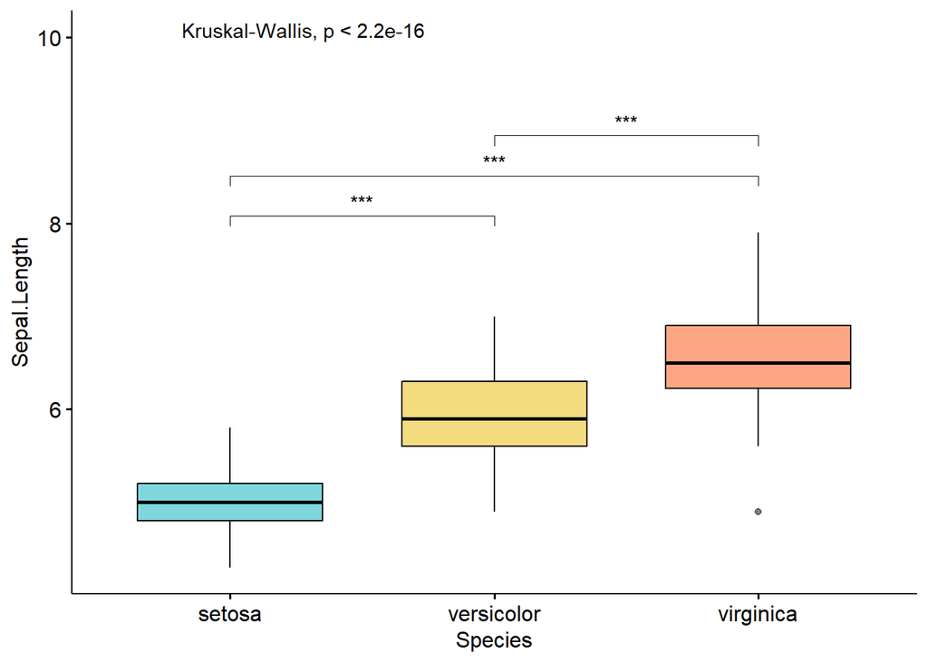

```r
# 设定显著性水平α=0.05
a <- 0.05

# 示例数据
dat <- iris[c("Sepal.Length","Species")]

# 1. Kruskal-Wallis检验
krus_rest <- stats::kruskal.test(Sepal.Length ~ Species, data = dat)
# 结果如下，p-value < a，表明拒绝H0，认为组别之间中位数（或分布）不相同
#   Kruskal-Wallis rank sum test
# data:  Sepal.Length by Species
# Kruskal-Wallis chi-squared = 96.937, df = 2, p-value < 2.2e-16

# 2. 事后检验（多重比较）
# 可以使用非参数方法Dunn检验、Conover-Iman检验或DSCF(Dwass–Steel–Critchlow–Fligner)检验
comp_rest1 <- FSA::dunnTest(Sepal.Length ~ Species, data = iris, method = "bonferroni")
comp_rest2 <- PMCMRplus::kwAllPairsConoverTest(iris$Sepal.Length, iris$Species, p.adjust.method = "holm")
comp_rest3 <- PMCMRplus::dscfAllPairsTest(Sepal.Length ~ Species, data = iris)
# 结果如下，p<a，表明三组之间都有显著差异
# > comp_rest1
# Dunn (1964) Kruskal-Wallis multiple comparison
#   p-values adjusted with the Bonferroni method.
#               Comparison         Z      P.unadj        P.adj
# 1    setosa - versicolor -6.106326 1.019504e-09 3.058513e-09
# 2     setosa - virginica -9.741785 2.000099e-22 6.000296e-22
# 3 versicolor - virginica -3.635459 2.774866e-04 8.324597e-04
# > comp_rest2
#   Pairwise comparisons using Conover's all-pairs test
# data: iris$Sepal.Length and iris$Species
#            setosa  versicolor
# versicolor < 2e-16 -
# virginica  < 2e-16 8.6e-09
# P value adjustment method: holm
# > comp_rest3
#   Pairwise comparisons using Dwass-Steele-Critchlow-Fligner all-pairs test
# data: Sepal.Length by Species
#            setosa  versicolor
# versicolor 2.6e-13 -
# virginica  3.1e-14 1.7e-06
# P value adjustment method: single-step

# 3. 结果可视化，注意这里，整体显著性用kruskal.test标记，组间还是用的wilcox.test
# 加载包
library(ggplot2)
library(ggpubr)
vars <- unique(dat$Species) %>% as.vector()
varscomb <- combn(vars,2,simplify=F)
ggboxplot(dat, x = "Species", y = "Sepal.Length", fill = "Species",
         palette = c("#00AFBB", "#E7B800", "#FC4E07", "#6EA8FD"), alpha=0.5)+
  # 添加显著性标记，方法t.test、wilcox.test、anova等，comparisons时不能用anova
  stat_compare_means(
    comparisons = varscomb,
    method = "wilcox.test",
    symnum.args = list(cutpoints = c(0, 0.001, 0.01, 0.05, Inf),
                       symbols = c("***", "**", "*", "NS")),
    label = "p.signif")+
  # 添加全局P值标记，没有comparisons是全局的
  stat_compare_means(label.y = 10, method = "kruskal.test")+
  theme(legend.position = "none")
```

### 案例4. 非参数多因素扩展

当数据不满足正态性、方差齐次性，并且想做多因素组间比较时，可采用非参数多因素扩展

这里主要指Scheirer Ray Hare检验，属于非参数方法，不依赖数据满足正态性或方差齐性假设，可用于多组比较，包括多因素设计和交互效应分析，是Kruskal-Wallis检验的多因素扩展

R语言中，使用`rcompanion::scheirerRayHare`函数执行Scheirer Ray Hare检验，其参数和含义如下：

1. `formula`：公式
2. `data`：数据
3. `y`：向量，因变量（响应变量），若未用formula指定，需直接传入
4. `x1`, `x2`：分类向量（因子或字符），若未用formula指定，需直接传入
5. `type`：整数1或2，用于指定平方和（SS）的计算方法：
   - `type=1`，序贯型平方和（Sequential SS），按模型中的变量顺序计算（先主效应后交互效应）
   - `type=2`，部分型平方和（Partial SS，默认），控制其他变量的影响后计算（更常用）
   - 若无交互效应或变量间独立，1或2结果相似，若存在交互效应，推荐2
6. `tie.correct`：逻辑值，是否对数据中的结（ties，即相同值的秩）进行校正默认TRUE
7. `ss`：逻辑值，是否在结果中返回平方和（SS）和均方（MS），默认TRUE
8. `verbose`：逻辑值，是否打印详细结果（如检验统计量、p 值），默认TRUE

```r
# 设定显著性水平α=0.05
a <- 0.05

# 数据来自datasets
dat <- ToothGrowth
dat$dose <- factor(dat$dose)
dat$supp <- factor(dat$supp)

# 1. 执行Scheirer Ray Hare检验
model <- rcompanion::scheirerRayHare(len ~ supp * dose, dat, type = 2, tie.correct = T, verbose = T)

# 结果如下，结果表明，主效应dose的p<a，supp和交互效应p>a，说明dose组间差异显著，而supp与交互效应不显著
# > model
#           Df  Sum Sq      H p.value
# supp       1  1050.0  3.445 0.06343
# dose       2 12394.4 40.669 0.00000
# supp:dose  2   515.5  1.692 0.42923
# Residuals 54  4021.1
# 注意上述结果，与相同数据、公式下的多因素ANOVA结果不同（案例1.2），主要体现在supp和交互效应是否显著上：
# 多因素ANOVA
# model <- anova_test(dat, len ~ supp * dose, detailed = T) %>%
#   get_anova_table() %>%
#   setDT() %>%
#   .[, R2:=SSn/(SSn + SSd)]         #计算各效应的R²
# 结果如下，p<a，表明拒绝原假设，认为各组均值不相等
# > model
#       Effect      SSn     SSd   DFn   DFd      F        p  p<.05   ges        R2
#       <char>    <num>   <num> <num> <num>  <num>    <num> <char> <num>     <num>
# 1:      supp  205.350 712.106     1    54 15.572 2.31e-04      * 0.224 0.2238254
# 2:      dose 2426.434 712.106     2    54 92.000 4.05e-18      * 0.773 0.7731092
# 3: supp:dose  108.319 712.106     2    54  4.107 2.20e-02      * 0.132 0.1320279

# 2. 事后多重比较，判断哪些组别之间均值不等
# 可以使用非参数方法Dunn检验或Conover-Iman检验对某个主效应进行检验，
# 或使用Aligned Rank Transform检验交互效应
# 对supp主效应的Dunn检验
# res1 <- FSA::dunnTest(len ~ supp, data = dat, method = "holm")             #这里分组小于等于2，报错
res1 <- PMCMRplus::kwAllPairsConoverTest(dat$len, dat$supp, method = "BH")
# 对dose主效应的Conover-Iman检验
res2 <- PMCMRplus::kwAllPairsConoverTest(dat$len, dat$dose, method = "BH")
# 对supp:dose交互效应的对齐秩变换检验
res3 <- ARTool::art(len ~ supp * dose, data = dat) %>% ARTool::art.con("supp:dose")
# 结果如下：
# > res1
#    OJ
# VC 0.063
# > res2
#   0.5     1
# 1 1.6e-07 -
# 2 1.1e-11 2.0e-05
# > res3
#  contrast        estimate   SE df t.ratio p.value
#  OJ,0.5 - OJ,1     -22.25 3.86 54  -5.766  <.0001
#  OJ,0.5 - OJ,2     -30.65 3.86 54  -7.942  <.0001
#  OJ,0.5 - VC,0.5     9.60 3.86 54   2.488  0.1460
#  OJ,0.5 - VC,1      -7.40 3.86 54  -1.918  0.4030
#  OJ,0.5 - VC,2     -30.00 3.86 54  -7.774  <.0001
#  OJ,1 - OJ,2        -8.40 3.86 54  -2.177  0.2655
#  OJ,1 - VC,0.5      31.85 3.86 54   8.253  <.0001
#  OJ,1 - VC,1        14.85 3.86 54   3.848  0.0041
#  OJ,1 - VC,2        -7.75 3.86 54  -2.008  0.3513
#  OJ,2 - VC,0.5      40.25 3.86 54  10.430  <.0001
#  OJ,2 - VC,1        23.25 3.86 54   6.025  <.0001
#  OJ,2 - VC,2         0.65 3.86 54   0.168  1.0000
#  VC,0.5 - VC,1     -17.00 3.86 54  -4.405  0.0007
#  VC,0.5 - VC,2     -39.60 3.86 54 -10.261  <.0001
#  VC,1 - VC,2       -22.60 3.86 54  -5.856  <.0001
# P value adjustment: tukey method for comparing a family of 6 estimates

# 3. 结果可视化，与1.2相同，这里省略
```

### 案例5. 稳健ANOVA

当数据为小样本、不满足正态性、方差齐次性，并且想做单因素或多因素组间比较时，可使用稳健ANOVA方法

这里主要指WRS2中的均值修剪方差分析，它是一种广义的Welch方法。它通过修剪均值进行单因素方差分析，可减少极端值对分析结果的影响，适用于数据含有离群点或方差不均的情况。

在R语言WRS2包中，应用`t1way`、`t2way`和`t3way`函数用于均值截断方差分析，它们分别用于单因素、双因素和三因素情况。其中参数如下：

1. `formula`: 公式
2. `data`: 数据框
3. `tr`：数值型，修剪比例，默认0.2，表示去除数据的上下各20%的部分，用来计算修剪均值
4. `alpha`：数值型，显著性水平，默认值是0.05，用于判断结果是否显著
5. `nboot`：数值型，启用自助法（bootstrap）时的模拟次数，默认是100次，用于计算置信区间或p值。

**单因素案例**

```r
# 设定显著性水平α=0.05
a <- 0.05

# 数据来自WRS2
set.seed(123)
dat <- WRS2::viagra

# 1. 均值截断方差分析（单因素）
tanova_result <- WRS2::t1way(libido ~ dose, data = dat)
# 结果如下，p>a，说明不能拒绝H0，认为各种用药剂量对没有影响
# Show in New Window
# Call:
# t1way(formula = libido ~ dose, data = viagra)
# Test statistic: F = 3
# Degrees of freedom 1: 2
# Degrees of freedom 2: 4
# p-value: 0.16
# Explanatory measure of effect size: 0.79
# Bootstrap CI: [0.57; 1.57]
# 注意这里效应量为0.79，即使结果不显著，效应也比较明显

# 2. 事后多重比较，判断哪些组别之间均值不等
after_result <- WRS2::lincon(libido ~ dose, data = dat)
# 结果如下，
# > after_result
# Call:
# lincon(formula = libido ~ dose, data = dat)
#                  psihat ci.lower ci.upper p.value
# placebo vs. low      -1 -5.31858  3.31858 0.43533
# placebo vs. high     -3 -7.31858  1.31858 0.18051
# low vs. high         -2 -6.31858  2.31858 0.31660
# 结果中，psihat是估计效应值，指每对比较的效应大小，表示两个组之间的均值差异
# 这里-1表示placebo比low低1个单位，类似的placebo比high低3个单位low比high低2个单位

# 3. 结果可视化，与1.1相同，这里省略
```

**多因素案例**

```r
# 设定显著性水平α=0.05
a <- 0.05

# 数据来自WRS2
set.seed(123)
dat <- WRS2::movie

# 1. 均值截断方差分析（多因素）
tanova_result <- WRS2::t3way(aggressive ~ degree*gender*type, data = dat)
# 结果如下，只有gender:type的p<a，其余p>a，说明大部分组不能拒绝H0，大部分组间均值差异不显著
# > tanova_result
# Call:
# t3way(formula = aggressive ~ degree * gender * type, data = dat)
#                        value p.value
# degree             3.3089497   0.085
# gender             1.3845004   0.260
# type               1.7102122   0.207
# degree:gender      3.6013168   0.073
# degree:type        0.3918961   0.540
# gender:type        8.7595078   0.008
# degree:gender:type 3.2614250   0.087

# 2. 事后多重比较，判断哪些组别之间均值不等
# 正确方法，同案例4
# 可以使用非参数方法Dunn检验或Conover-Iman检验对某个主效应进行检验，
# 或使用Aligned Rank Transform检验交互效应
# 对degree主效应的Dunn检验
# res1 <- FSA::dunnTest(aggressive ~ degree, data = dat, method = "holm")    #这里分组小于等于2，报错
res1 <- PMCMRplus::kwAllPairsConoverTest(dat$aggressive, dat$degree, method = "BH")
# 对gender主效应的Conover-Iman检验
res2 <- PMCMRplus::kwAllPairsConoverTest(dat$aggressive, dat$gender, method = "BH")
# 对degree:gender交互效应的对齐秩变换检验
res3 <- ARTool::art(aggressive ~ degree * gender, data = dat) %>% ARTool::art.con("degree:gender")
# 结果如下：
# > res1
#   Pairwise comparisons using Conover's all-pairs test
# data: dat$aggressive and dat$degree
#        no degree
# degree 0.17
# P value adjustment method: single-step
# > res2
#   Pairwise comparisons using Conover's all-pairs test
# data: dat$aggressive and dat$gender
#        male
# female 0.71
# P value adjustment method: single-step
# > res3
#  contrast                          estimate   SE df t.ratio p.value
#  degree,female - degree,male          12.22 6.56 64   1.863  0.2541
#  degree,female - no degree,female     17.59 6.75 64   2.606  0.0540
#  degree,female - no degree,male        8.97 6.56 64   1.368  0.5240
#  degree,male - no degree,female        5.37 6.56 64   0.819  0.8454
#  degree,male - no degree,male         -3.25 6.36 64  -0.511  0.9563
#  no degree,female - no degree,male    -8.62 6.56 64  -1.314  0.5574
# P value adjustment: tukey method for comparing a family of 4 estimates

# 错误方法：
# after_result <- WRS2::lincon(aggressive ~ degree*gender*type, data = dat)
# 注意，多因素情况，不要用WRS2::lincon，原因是
# 即便可以用A:B或A*B公式传入，但其运行的还是A的单因素分析，示例数据和结果如下
# 此外，单因素type如果只有2组，则结果不会有如下这么详细
# > WRS2::lincon(value ~ type1*type2, data = dat)
# Call:
# WRS2::lincon(formula = value ~ type1 * type2, data = dat)
#           psihat ci.lower ci.upper p.value
# A vs. B -0.19613 -1.02741  0.63515 0.71106
# A vs. C  0.14024 -0.89231  1.17279 0.71106
# B vs. C  0.33637 -0.75783  1.43058 0.71106
# > WRS2::lincon(value ~ type1:type2, data = dat)
# Call:
# WRS2::lincon(formula = value ~ type1:type2, data = dat)
#           psihat ci.lower ci.upper p.value
# A vs. B -0.19613 -1.02741  0.63515 0.71106
# A vs. C  0.14024 -0.89231  1.17279 0.71106
# B vs. C  0.33637 -0.75783  1.43058 0.71106
# > WRS2::lincon(value ~ type1, data = dat)
# Call:
# WRS2::lincon(formula = value ~ type1, data = dat)
#           psihat ci.lower ci.upper p.value
# A vs. B -0.19613 -1.02741  0.63515 0.71106
# A vs. C  0.14024 -0.89231  1.17279 0.71106
# B vs. C  0.33637 -0.75783  1.43058 0.71106

# 3. 结果可视化，与1.2相同，这里省略
```

### 案例6. 显著性标记绘图总结

总结了显著性标记的几种方法

注意

1. bar，errorbar和text的position参数要相同
2. ggplot2中，调整errorbar图层至bar图层前面，可实现显示上半个errorbar，在ggpubr包中，可使用`error.plot = "upper_errorbar"`显示半个
3. 对于条形图，`ggplot()+geom_bar(stat="identity")`与`ggplot()+geom_col()`效果相同
4. 不想让aes继承，可以用这个参数inherit.aes = FALSE
5. ggplot2中只有mean_sdl，默认mult=2，即取值范围是mean±2*sd，而ggpubr中有mean_sd
6. 标记图层继承多行数据行时，geom_text可能会警告，解决办法是用`annotate`或者是用`inherit.aes=F`
7. 用`ggpubr`+`rstatix`实现检验和标记，此外，也可以用`ggsignif::geom_signif`包
8. Kruskal-Wallis检验，可识别多组独立样本的中位数是否有差别（至少有一组的中位数与其他组不同），相当于非参数版的单因素方差分析
9. Wilcoxon秩和检验，又名Mann-Whitney-U检验，可识别两组独立样本的中位数或分布差异，相当于非参数版的独立样本t检验

#### 1. 单因素标记

**（1）分布图（boxplot或violin）+内部检验+显著性成对标记（星号或p值）**

此种情况，使用使用全部数据，无需统计变换，检验和标记也用ggpubr内部方法，相对简单，但可调节选项稍微少一些，虽然ggpubr绘图与ggplot2可以无缝衔接

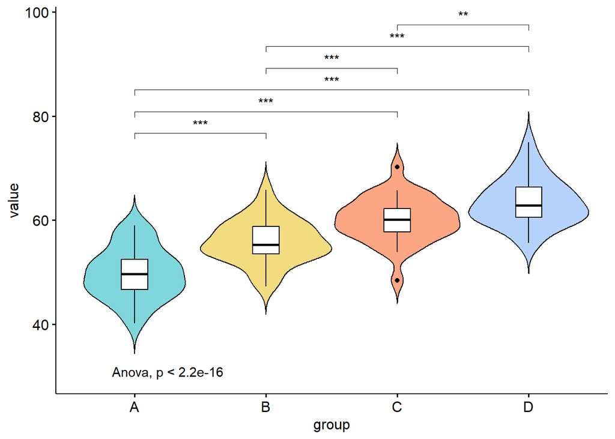

```r
# 加载包
library(ggplot2)
library(ggpubr)

# 设定显著性水平α=0.05
a <- 0.05

# 生成四组数据
set.seed(123)
groupA <- rnorm(30, mean = 50, sd = 5)
groupB <- rnorm(30, mean = 55, sd = 5)
groupC <- rnorm(30, mean = 60, sd = 5)
groupD <- rnorm(30, mean = 64, sd = 5)

# 数据框整理
dat <- data.frame(
  value = c(groupA, groupB, groupC, groupD),
  group = factor(rep(c("A", "B", "C", "D"), each = 30))
)

# 绘图
vars <- unique(dat$group) %>% as.vector()
varscomb <- combn(vars,2,simplify=F)
ggviolin(dat, x = "group", y = "value", fill = "group",
         palette = c("#00AFBB", "#E7B800", "#FC4E07", "#6EA8FD"), alpha=0.5,
         add = "boxplot", add.params = list(fill = "white"))+
  # 添加标记，有comparisons是成对的，方法包括t.test、wilcox.test（成对时不能用anova这种全局的）
  stat_compare_means(
    comparisons = varscomb,
    method = "wilcox.test",
    symnum.args = list(cutpoints = c(0, 0.001, 0.01, 0.05, Inf),
                       symbols = c("***", "**", "*", "NS")),
    label = "p.signif")+
  # 添加标记，没有comparisons是全局的，标记整体显著性，方法包括anova等（整体是不能用t.test这种成对的，会重叠）
  stat_compare_means(label.y = 30, method = "anova")+
  theme(legend.position = "none")
```

**（2）均值图（barplot或point）+误差（se或sd）+外部检验+显著性成对标记（星号或p值）**

此种情况，使用使用全部数据+统计变换（此处用ggpubr包免变换），区别与上面，这里用外部检验，稍微放宽了对ggpubr的依赖，可调参数稍多一些。

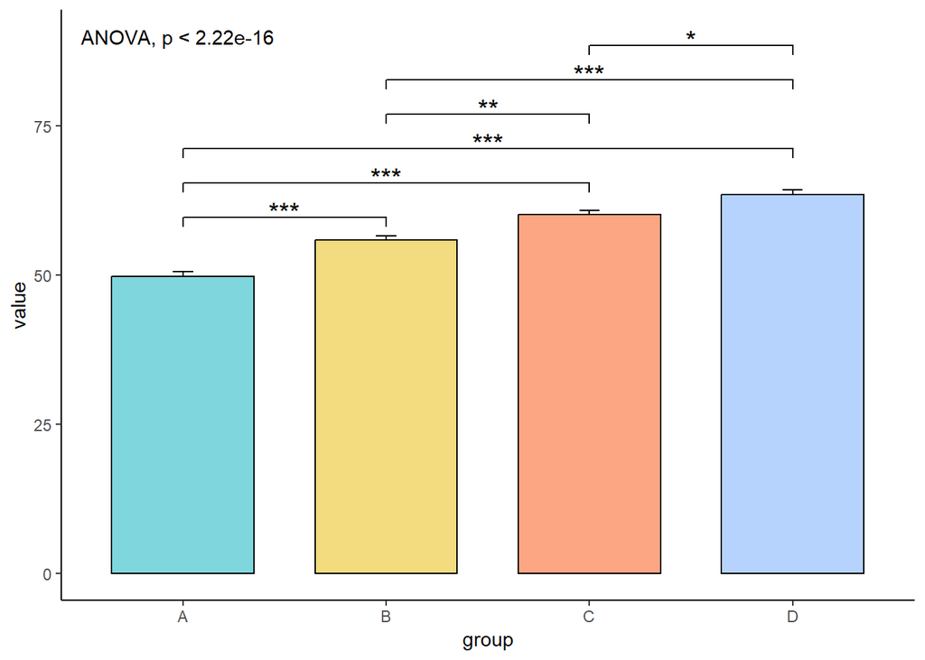

```r
# 加载包
library(ggplot2)
library(ggpubr)
# library(rstatix)
library(magrittr)

# 设定显著性水平α=0.05
a <- 0.05

# 生成四组数据
set.seed(123)
groupA <- rnorm(30, mean = 50, sd = 5)
groupB <- rnorm(30, mean = 55, sd = 5)
groupC <- rnorm(30, mean = 60, sd = 5)
groupD <- rnorm(30, mean = 64, sd = 5)

# 数据框整理
dat <- data.frame(
  value = c(groupA, groupB, groupC, groupD),
  group = factor(rep(c("A", "B", "C", "D"), each = 30))
)

# 统计检验（Wilcoxon秩和检验，Bonferroni校正）
stat.test <- dat %>%
  rstatix::wilcox_test(value~group, p.adjust.method = "bonferroni") %>%
  rstatix::add_xy_position(x = "group", data = dat, step.increase = 0.3)     #添加作图属性

# 修改显著性符号（等效于上面的symnum.args）
stat.test <- stat.test %>%
  dplyr::mutate(
    p.signif_manu = dplyr::case_when(
      p.adj < 0.001 ~ "***",
      p.adj < 0.01  ~ "**",
      p.adj < 0.05  ~ "*",
      TRUE          ~ "NS"  # 不显著
    )
  )

# 计算全局检验（ANOVA或Kruskal-Wallis）
global_p <- aov(Sepal.Length ~ Species, data = iris) %>% summary() %>% {.[[1]]["Pr(>F)"][1, 1]}
# global_p <- kruskal.test(Sepal.Length ~ Species, data = iris)$p.value

# 将p值格式化为文本（带方法名称）
formatted_p <- paste0("ANOVA, p",
                      ifelse(grepl("<", format.pval(global_p)), " ", " = "),
                      format.pval(global_p))

# 绘图
ggbarplot(dat, x = "group", y = "value", fill = "group",
          palette = c("#00AFBB", "#E7B800", "#FC4E07", "#6EA8FD"), alpha=0.5,
          add = "mean_se", error.plot = "upper_errorbar")+                     #ggplot没有upper_errorbar方法
  # 添加全局P值标记
  annotate("text", x=0.5, y=90, label=formatted_p, hjust=0)+
  # 添加配对显著性标记
  stat_pvalue_manual(
    stat.test,
    y.position = stat.test$y.position-20,  #整体下移20
    label = "p.signif_manu",               #label所在变量
    tip.length = 0.03,                     #括号（“连接线”）的两边长度（0=无横线）
    bracket.size = 0.5,                    #括号的线粗
    label.size = 5,                        #显著性标签（如 "***"）字体大小
    inherit.aes = FALSE                    #不继承主图的 aes 映射（自己指定的变量）
  )+
  theme_classic()+
  theme(legend.position = "none")
```

**（3）均值图（barplot或point）+误差（se或sd）+外部检验+显著性整体标记（字母）**

此种情况，使用使用全部数据+统计变换（此处用ggplot2包变换），这里使用ggplot2包，可调参数最多

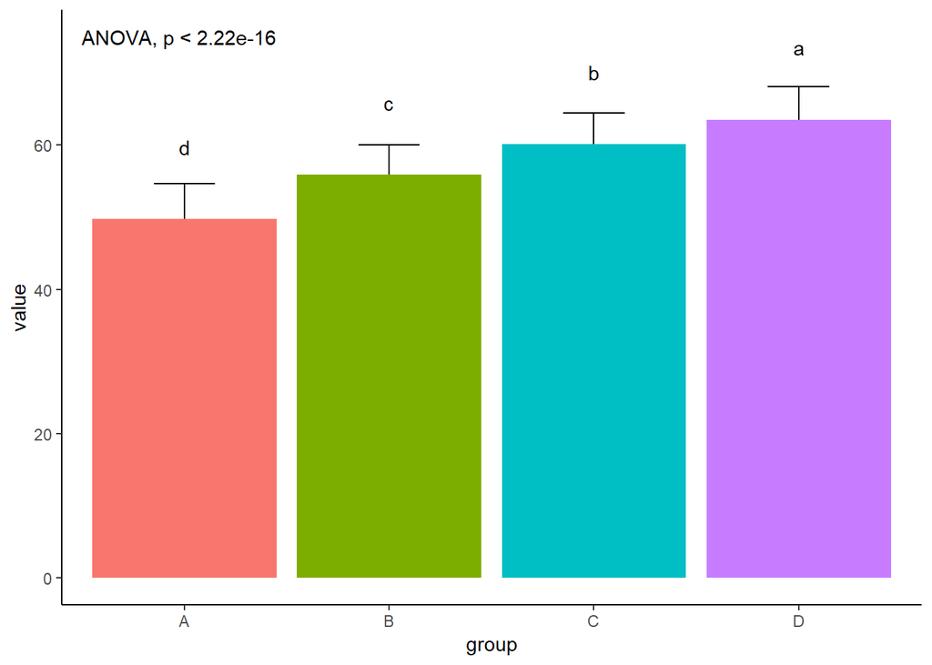

```r
# 加载包
library(ggplot2)
library(magrittr)
library(multcomp)
library(emmeans)

# 设定显著性水平α=0.05
a <- 0.05

# 生成四组数据
set.seed(123)
groupA <- rnorm(30, mean = 50, sd = 5)
groupB <- rnorm(30, mean = 55, sd = 5)
groupC <- rnorm(30, mean = 60, sd = 5)
groupD <- rnorm(30, mean = 64, sd = 5)

# 数据框整理
dat <- data.frame(
  value = c(groupA, groupB, groupC, groupD),
  group = factor(rep(c("A", "B", "C", "D"), each = 30))
)

# 字母显著性创建方法1，用emmeans::emmeans线性假设，结果可能与aov的Tukey不同，但是df型，可以直接用（推荐）
cld_result1 <- aov(value ~ group, data = dat) %>%
  emmeans::emmeans(~ group) %>%
  # graphics::pairs(adjust = "tukey") %>%    #显式应用Tukey，不要加这句，否则就是成对的字母显著性标记
  multcomp::cld(Letters = letters, decreasing = T)
cld_result1$.group <- stringr::str_trim(cld_result1$.group)  #标记两侧有空格

# 字母显著性创建方法2，用multcomp::glht的Tukey方法，结果只是一个向量，如需绘图还得整理（不推荐）
# cld_result2 <- aov(value ~ group, data = dat) %>%
#   multcomp::glht(linfct = mcp(group = "Tukey")) %>%
#   multcomp::cld(decreasing = T)          #这里参数Letters = LETTERS不起作用

# 字母显著性创建方法3，用agricolae包，支持单因素HSD.test或LSD.test，标记字母是向量形式（不推荐）
# cld_result3 <- aov(value ~ group, data = dat) %>%
#   agricolae::HSD.test("group")

# 计算全局检验（ANOVA或Kruskal-Wallis）
global_p <- aov(Sepal.Length ~ Species, data = iris) %>% summary() %>% {.[[1]]["Pr(>F)"][1, 1]}
# global_p <- kruskal.test(Sepal.Length ~ Species, data = iris)$p.value

# 将p值格式化为文本（带方法名称）
formatted_p <- paste0("ANOVA, p",
                      ifelse(grepl("<", format.pval(global_p)), " ", " = "),
                      format.pval(global_p))

# 绘图
ggplot(dat, aes(group, value, fill=group))+
  stat_summary(fun.data = ggpubr::mean_sd, geom = "errorbar", width=0.3)+       #ggplot2只能放在col下面以隐藏下半errorbar
  stat_summary(fun = mean, geom = "col", show.legend = F)+
  annotate("text", x=0.5, y=75, label=formatted_p, hjust=0)+
  geom_text(data = cld_result1, aes(y=emmean+10,label=.group))+
  theme_classic()
```

#### 2. 双因素标记

**（1）分布图（boxplot或violin）/均值误差图（barplot或point+se或sd）+外部检验+显著性分组标记（星号或p值）**

此种情况，自定义了一个标记函数，对分布或变换数据无要求，使用ggplot2，标记每个x轴对应组别内部的，关于分类变量之间的显著性

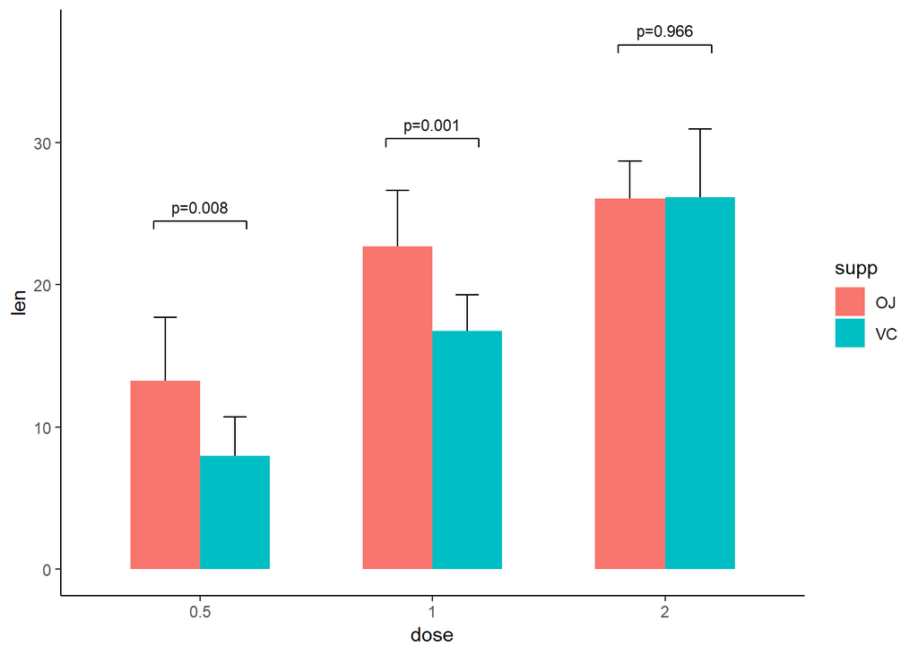

```r
# 加载包
library(magrittr)
library(data.table)
library(ggplot2)
library(multcomp)
library(ggsci)
library(stringr)
library(magrittr)

# 设定显著性水平α=0.05
a <- 0.05

# 数据来自datasets
dat <- ToothGrowth
dat$dose <- factor(dat$dose)
dat$supp <- factor(dat$supp)

# 定义一个函数，生成双因素方差结果图的显著性成对标记图层
# 成对标记为，x轴方向+class分类变量，在doge形式上，标记每个x类别对应的class组间对比
pairs_sig_mark <- function(data, yn, xn, cn, xlength=0.4, ylengths=0.02, yheighs=0.1, theighs=0.02, is_pvalue=F,
                           p_dig=3, linewidth=0.5, size=4, ...){
  # data：绘图数据（在...中传递）
  # yn,xn,cn：分别是y轴、x轴、分类的变量所在列号，每个变量一个
  # xlength：横向标记线长度，绝对值
  # ylengths：竖向标记线（横向两端）长度乘数（长度为数据y范围*yscale），0-1之间
  # yheighs：横向标记线的高度位置尺度（高度为数据y最大值+y范围*yvscale），0-1之间
  # theighs：文字标记的高度位置尺度（高度为yvscale+范围*tvscale），0-1之间
  # is_pvalue：显著性标记p值还是星号
  # p_dig：p值小数位数，低于此精度p值显示小于号

  # 获取、定制数据基本信息
  setDT(data)
  ocolname <- names(data)
  sigdata <- data[, .SD, .SDcols = c(yn, xn, cn)] %>%
    set_colnames(c("yy","xx","cc"))
  xx_level <- unique(sigdata$xx)                      #x轴上分类个个数
  yrange <- range(sigdata$yy) %>% diff() %>% abs()    #y轴范围尺度，全局数据

  # 每组显著性，x轴变量的每组下，对class变量单独做单因素方差分析，提取结果
  p_value <- rep(0, length(xx_level))
  for(i in seq_along(xx_level)){
    p_value[i] <- sigdata[xx==xx_level[i], ] %>% rstatix::anova_test(yy~cc, white.adjust = T) %>% .[,"p"]
  }
  if(isTRUE(is_pvalue)) {                              #返回p值还是星号
    signal_text <- ifelse(p_value<10^(-p_dig), paste0("p<1e-",p_dig), sprintf(paste0("p=%.",p_dig,"f"),p_value))
  } else {
    signal_text <- ifelse(p_value <= 0.001, "***",
                          ifelse(p_value <= 0.01,  "**",
                                 ifelse(p_value <= 0.05,  "*", "NS")))
  }

  # 显著性标线数据，横向部分
  sigdata_x <- copy(sigdata) %>%
    .[,.(yymax=max(yy)+yrange*yheighs), by=c("xx")] %>%                  #指定横线y坐标
    .[, xcen:=1:length(xx_level)] %>%                                    #指定横线中心x坐标
    .[, c("xleft", "xright"):=list(xcen-xlength/2, xcen+xlength/2)]      #由中心向两端延伸出端点x坐标

  # 显著性标线数据，纵向部分
  sigdata_y <- copy(sigdata_x) %>%
    melt(id=c("xx", "yymax", "xcen"), value.name = "xendpoint") %>%      #指定竖线x坐标、上端y坐标（即yymax）
    .[, yymin:=yymax-yrange*ylengths]                                    #指定竖线下端y坐标

  # 显著性文字
  sigdata_text <- copy(sigdata_x) %>%
    .[,ycen:=yymax+yrange*theighs] %>%                                   #指定显著性文字y坐标
    .[,p_l:=signal_text]                                                 #指定显著性文字内容

  # 图层输出
  geom_list <- list(
    geom_linerange(data=sigdata_x, aes(y=yymax, xmin=xleft, xmax=xright), show.legend=F, inherit.aes=F, linewidth=linewidth, ...),
    geom_linerange(data=sigdata_y, aes(x=xendpoint, ymin=yymin, ymax=yymax), show.legend=F, inherit.aes=F, linewidth=linewidth, ...),
    geom_text(data=sigdata_text, aes(xcen, ycen, label=p_l), show.legend=F, inherit.aes=F, hjust=0.5, vjust=0, size=size, ...)
  )
  return(geom_list)
}

# 绘图
ggplot(data=dat, aes(dose, len, fill=supp))+
  # geom_violin(trim=F)+
  stat_summary(fun.data = ggpubr::mean_sd, geom="errorbar", width=0.2, position=position_dodge(width=0.6))+           #ggplot2中只有mean_sdl，其中为2*sd
  stat_summary(fun=mean, geom="col", width=0.6, position=position_dodge(width=0.6))+
  pairs_sig_mark(data=dat, yn=1,xn=3,cn=2, is_pvalue=T,linewidth=0.5,size=3)+
  theme_classic()
```

**（2）均值和误差（barplot或point+se或sd）+外部检验+显著性整体标记（字母）**

此种情况，使用使用全部数据+统计变换（此处用ggplot2包变换），这里使用ggplot2包，可调参数最多

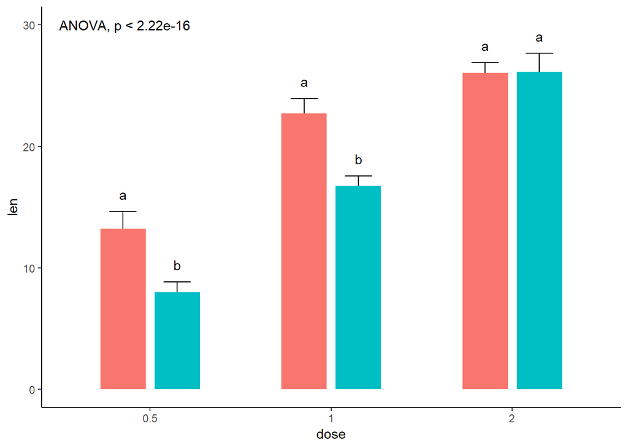

```r
# 加载包
library(magrittr)
library(data.table)
# library(rstatix)       #这个包会和其他包常用函数有冲突，如select、filter
library(ggplot2)
library(multcomp)
library(ggsci)
library(stringr)
library(magrittr)

# 设定显著性水平α=0.05
a <- 0.05

# 数据来自datasets
dat <- ToothGrowth
dat$dose <- factor(dat$dose)
dat$supp <- factor(dat$supp)

# 字母显著性创建方法1，用emmeans::emmeans的线性假设，结果可能与aov的Tukey不同，但是df型，可以直接用
cld_result_temp <- aov(len ~ supp*dose, data = dat) %>%          #注意这里需要考虑交互，否则结果不严谨
  emmeans::emmeans(~ supp|dose) %>%
  multcomp::cld(Letters = letters, decreasing = T) %>%
  setDT() %>%
  .[,.group:=stringr::str_trim(.group)]                         #标记两侧有空格

cld_result <- copy(dat) %>%
  setDT() %>%
  .[, .(se=sd(len)/sqrt(.N)), by=c("supp","dose")] %>%
  .[cld_result_temp, on=c("supp","dose")]

# 计算全局检验（ANOVA）
global_p <- aov(Sepal.Length ~ Species, data = iris) %>% summary() %>% {.[[1]]["Pr(>F)"][1, 1]}

# 将p值格式化为文本（带方法名称）
formatted_p <- paste0("ANOVA, p",
                      ifelse(grepl("<", format.pval(global_p)), " ", " = "),
                      format.pval(global_p))

# 绘图
pd <- position_dodge(width=0.6)
ggplot(dat, aes(dose, len, fill=supp))+
  stat_summary(fun.data = mean_se, geom = "errorbar", width=0.3, position = pd)+       #ggplot2只能放在col下面以隐藏下半errorbar
  stat_summary(fun = mean, geom = "col", width=0.5, position = pd, show.legend = F)+
  annotate("text", x=0.5, y=30, label=formatted_p, hjust=0)+
  geom_text(data = cld_result, aes(x=dose, y=emmean+se+1, label=.group), position = pd, hjust=0.5, vjust=0)+
  theme_classic()
```

#### 3. 自定义标记

早前写的，自定义函数版本，事先将数据汇总，并计算好显著性，然后画在图中，为了向bar图添加显著性标记，自定义了一个函数。

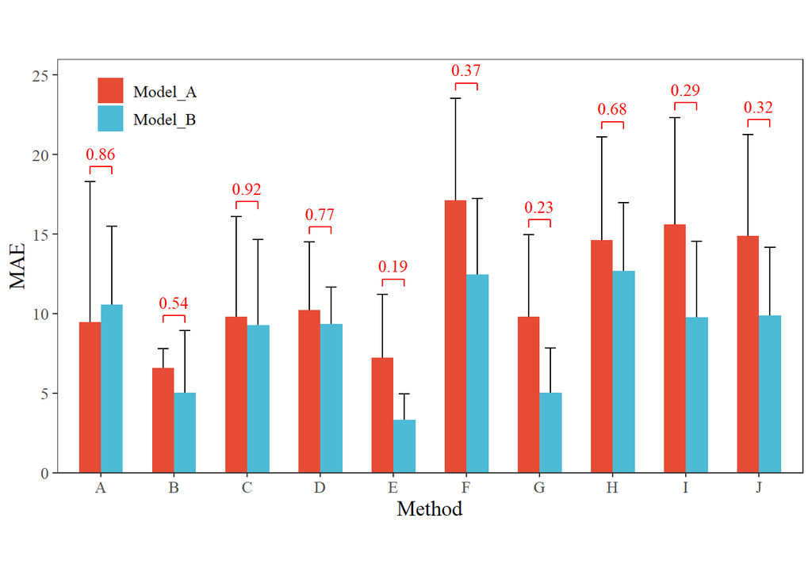

```r
# 加载所需包
library(magrittr)
library(data.table)
library(ggplot2)
library(multcomp)   #计算avo的pvalue
library(ggsci)
# library(ggsignif) #当画箱形图时，可用这个包

# 定义一个函数，生成均值方差和显著性标记线、标签（此处用的是方差分析）
data_material <- function(data, xdrift=0.15, ydrift=0.04, equleg=T){
  # xdrift和ydrift为xy方向偏移量，其中xdrift应为bar宽度width的一半，equleg设置标记的腿是否等长
  # 提取计算列，备份原列名，然后赋予新列名，便于后续计算
  con_data <- data[,1:3]
  ori_name <- colnames(con_data)
  names(con_data) <- c("xaxis", "compare", "value")

  #先按因子类型排序con_data
  setorder(con_data, xaxis, compare)

  # 生成均值、方差列
  data_msd <- con_data[, .(m=mean(value), sd=sd(value)), by=c("xaxis", "compare")]

  # 方差分析，生成p值显著性标签
  p.frame <- data.table(xaxis=unique(con_data$xaxis), p.value=NA_real_, p.label=NA_character_)
  for(i in p.frame$xaxis){
    tres <- aov(value~compare, con_data[xaxis==i,])
    tp <- glht(tres, linfct = mcp(compare = "Tukey")) %>% summary()
    p.frame[xaxis == i, p.value:=tp$test$pvalues]
    p.frame[xaxis == i, p.label:=ifelse(p.value<0.01, "***", ifelse(p.value<0.05, "**", ifelse(p.value<0.1, "*", "NS")))]
  }

  # 生成标记线图层
  data_msd[, msd:=m+sd]                      #添加一列，为mean+sd
  compare_lv1 <- levels(data_msd$compare)[1]
  compare_lv2 <- levels(data_msd$compare)[2]
  xcen <- seq_along(unique(data_msd$xaxis))  #x的中心位置，为fa1的变量个数
  xoff <- xdrift                             #x起止位置偏移量，为bar宽度的一半
  m_plus_sd <- data_msd[, max(msd), by=c("xaxis")]$V1
  unitdrift <- ydrift*max(m_plus_sd)           #全图中最大的mean+sd乘以偏移比，为单位偏移量
  ycen <- m_plus_sd+unitdrift                  #y中心位置，为m+sd加单位偏移量
  yleft <- data_msd[compare==compare_lv1, msd]+unitdrift*0.5 #左脚最低位置，为m+sd加0.5个单位偏移量
  yrigh <- data_msd[compare==compare_lv2, msd]+unitdrift*0.5 #右脚最低位置，为m+sd加0.5个单位偏移量
  if(isTRUE(equleg)) yleft <- yrigh <- pmax(yleft,yrigh)     #如果相同，则取最大的那个

  # 生成标记线和标签数据，p值默认两位小数
  sig_seg <- data.table(x0=c(xcen-xoff, xcen-xoff, xcen+xoff), x1=c(xcen-xoff, xcen+xoff, xcen+xoff),
                        y0=c(yleft, ycen, ycen), y1=c(ycen, ycen, yrigh))
  sig_lab <- data.table(x=xcen, y=ycen+unitdrift*0.5, p.value=sprintf("%.2f", p.frame$p.value), p.label=p.frame$p.label)

  # 恢复数据列名
  names(data_msd) <- c(ori_name[1:2], "m", "sd","msd")
  names(p.frame) <- c(ori_name[1], "p.value", "p.label")

  # 输出结果
  res <- list(data.msd=data_msd, sig.segment=sig_seg, sig.label=sig_lab)
  return(res)
}

# 数据，第一列是x轴，第二列是对比类（只有两类），第三列是数据
# 其中，第一、二列必须是因子型，顺序是已定义的
data <- data.table(method = c('B', 'B', 'B', 'A', 'A', 'A', 'C', 'C', 'C', 'D', 'D', 'D',
                              'E', 'E', 'E', 'F', 'F', 'F', 'G', 'G', 'G', 'H', 'H', 'H',
                              'I', 'I', 'I', 'J', 'J', 'J', 'B', 'B', 'B', 'A', 'A', 'A',
                              'C', 'C', 'C', 'D', 'D', 'D', 'E', 'E', 'E', 'F', 'F', 'F',
                              'G', 'G', 'G', 'H', 'H', 'H', 'I', 'I', 'I', 'J', 'J', 'J'),
                   model = c('B', 'B', 'B', 'B', 'B', 'B', 'B', 'B', 'B', 'B', 'B', 'B', 'B',
                             'B', 'B', 'B', 'B', 'B', 'B', 'B', 'B', 'B', 'B', 'B', 'B', 'B',
                             'B', 'B', 'B', 'B', 'A', 'A', 'A', 'A', 'A', 'A', 'A', 'A', 'A',
                             'A', 'A', 'A', 'A', 'A', 'A', 'A', 'A', 'A', 'A', 'A', 'A', 'A',
                             'A', 'A', 'A', 'A', 'A', 'A', 'A', 'A'),
                   MAE = c(9.04, 1.20, 4.80, 16.24, 7.80, 7.63, 15.38, 7.33, 5.10, 10.14,
                           6.77, 11.20, 2.49, 5.20, 2.33, 15.78, 7.00, 14.63, 8.18, 2.73,
                           4.13, 16.18, 7.87, 13.97, 14.51, 4.93, 9.87, 14.44, 5.93, 9.30,
                           7.60, 5.24, 6.94, 19.08, 7.59, 1.69, 16.95, 7.39, 5.09, 14.59,
                           6.03, 10.08, 8.66, 10.31, 2.71, 23.00, 10.28, 18.10, 15.75, 7.13,
                           6.50, 20.84, 7.90, 15.17, 21.33, 8.25, 17.28, 20.63, 8.07, 15.99))
method_lev <- c("A","B","C","D","E","F","G","H","I","J")
model_lev <- c("A", "B")
data[, method:=factor(method, levels = method_lev)]
data[, model:=factor(model, levels = model_lev)]

# 生成均值方差、和显著性数据
res <- data_material(data)
data_msd <- res$data.msd
sig_seg <- res$sig.segment
sig_lab <- res$sig.label

# 画图
ggplot(data_msd, aes(method, m, fill = model))+
  geom_errorbar(aes(ymin= m-sd, ymax=m+sd), position = position_dodge(0.6), width = 0.3)+
  geom_bar(stat = "identity", position = position_dodge(), width = 0.6)+
  scale_fill_npg(labels = c("Model_A", "Model_B"))+
  geom_segment(data = sig_seg, aes(x=x0, xend=x1, y=y0, yend=y1, fill=NULL), color="red")+
  geom_text(data=sig_lab, aes(x=x, y=y, label=p.value, fill=NULL), color="red", vjust=0, family = "serif")+    #可选，显示p值
  # geom_text(data=sig_lab, aes(x=x, y=y, label=p.label, fill=NULL), color="red", vjust=0, family = "serif")+  #可选，显示显著性符号
  scale_y_continuous(limits = c(0, 26), expand = c(0,0))+
  guides(fill = guide_legend(title = NULL))+
  labs(x = "Method", y = "MAE")+
  theme_bw()+
  theme(aspect.ratio = 1/1.8,
        axis.text = element_text(size = 10, family = "serif"),
        axis.title = element_text(size = 13, family = "serif"),
        text = element_text(family = "serif"),
        panel.grid = element_blank(),
        legend.text = element_text(size = 10),
        legend.position = c(0.12, 0.89),
        plot.title = element_text(hjust = 0.5))
```

### CLD-1: ANOVA

上面代码介绍了三种，对于ANONA结果创建紧凑字母显示（compact letter display, CLD），即显著性字母字母标记的方法：

- 方法1，用`emmeans::emmeans`线性假设，结果可能与aov的Tukey不同，但是df型，可以直接用（推荐）
- 方法2，用`multcomp::glht`的Tukey方法，结果只是一个向量，如需绘图还得整理（不推荐）
- 方法3，agricolae包，支持单因素`HSD.test`或`LSD.test`，标记字母是向量形式（不推荐）

下面分别解释其用法：

（1）方法1，用`emmeans::emmeans`线性假设，结果可能与aov的Tukey不同，但是df型，可以直接用（推荐）

emmeans（Estimated Marginal Means）:

- 是用于估计各组的边际均值的函数
- 输出是各个因子水平的边际均值（即调整后的均值），并可以基于这些均值进行多重比较
- emmeans的一个优势是它在考虑模型中协变量或其他影响因素后，能给出更精确的比较
- 仅在某些特殊用法中，会与下面两种在相同方法下，结果有差异，因此还是最推荐该方法

基础用法：

```r
cld_result1 <- aov(value ~ group, data = dat) %>%
  emmeans::emmeans(~ group) %>%
  # graphics::pairs(adjust = "tukey") %>%    #显式应用Tukey，不要加这句，否则就是成对的字母显著性标记
  multcomp::cld(Letters = letters, decreasing = T)
```

可通过如下方式，执行多因素的交互显著性标记（标记效应）

```r
# 数据准备
dat <- ToothGrowth
dat$dose <- factor(dat$dose)
dat$supp <- factor(dat$supp)

# 执行ANOVA
model <- aov(len ~ dose * supp, data = dat)
# 每个 dose 下，对 supp 水平计算边际均值
emmeans::emmeans(model, ~ supp | dose) %>% cld(Letters = letters, decreasing = TRUE)
```

（2）方法2，用`multcomp::glht`的Tukey方法，结果只是一个向量，如需绘图还得整理（不推荐）

glht（General Linear Hypothesis Test）：

- 是通用的线性假设检验工具， 可以用于各种类型的比较，包括单独的对比、多个对比，甚至是组合的对比。
- glht适用于更复杂的假设检验，可以使用linfct参数指定对比的方式（例如，Tukey检验）
- 其输出是关于对比（例如组间差异）的显著性结果
- 而两者都采用的`multcomp::cld`是一个用来将检验结果转换为字母标记的函数，这里会根据p值排序并标记显著性

基础用法：

```r
cld_result2 <- aov(value ~ group, data = dat) %>%
  multcomp::glht(linfct = mcp(group = "Tukey")) %>%
  multcomp::cld(decreasing = T)          #这里参数Letters = LETTERS不起作用
```

高级用法：

glht中的linfct可选多种参数，其含义和结果如下

- `factor`：模型中的因子变量（必须是factor类型）
- `linfct=mcp(factor = "comparison_method")`，comparison_method：指定多重比较的方法，常见的有：

```r
dat <- ToothGrowth
dat$dose <- factor(dat$dose)
dat$supp <- factor(dat$supp)
model <- aov(len~dose*supp, dat)
model <- aov(len~dose, dat)
glht(model, linfct = mcp(dose = "Tukey")) %>% summary()       #两两对比，TukeyHSD方法
glht(model, linfct = mcp(dose = "Dunnett")) %>% summary()     #Dunnett指定第一个因子为对照组，只能通过修改因子顺序来自定义
glht(model, linfct = mcp(dose = "Sequen")) %>% summary()      #顺序对比，后一组均值减前一组均值
glht(model, linfct = mcp(dose = "AVE")) %>% summary()         #各组均值与整体均值的比较，每组是否高于或低于整体平均
glht(model, linfct = mcp(dose = "Changepoint")) %>% summary() #检测从某组开始是否有显著跳跃/趋势，是否存在突变点
glht(model, linfct = mcp(dose = "Marcus")) %>% summary()      #s检测顺序差异，即mu_1-mu_0.5, mu_2-mu_0.5, mu_2-mu_1,
glht(model, linfct = mcp(dose = "Williams")) %>% summary()    #比较各个处理组与最高组
glht(model, linfct = mcp(dose = "McDermott")) %>% summary()   #比较各个处理组与最低组

# glht的结果可按如下分析：

# > glht(model, linfct = mcp(dose = "Changepoint")) %>% summary() #检测从某组开始是否有显著跳跃/趋势，是否存在剂量水平的“突变点”
# Simultaneous Tests for General Linear Hypotheses
# Multiple Comparisons of Means: Changepoint Contrasts
# Fit: aov(formula = len ~ dose, data = dat)
# Linear Hypotheses:
#   Estimate Std. Error t value Pr(>|t|)
# C 1 == 0   12.312      1.162  10.598   <1e-10 ***
# C 2 == 0   10.930      1.162   9.408   <1e-10 ***
#   ---
#   Signif. codes:  0 ‘***’ 0.001 ‘**’ 0.01 ‘*’ 0.05 ‘.’ 0.1 ‘ ’ 1
# (Adjusted p values reported -- single-step method)
# 这个结果表明，
# 是否从 0.5 → 1 出现了明显变化？是（C1）：mu_1-mu_0.5
# 是否从 0.5/1 到 2 出现进一步变化？是（C2）：2mu_2-mu_1-mu_0.5
```

注意，对于glht，虽然下面两个结果是不一样的，但是它仍然不能分析交互作用，因此多因素时，还是不可用

```r
aov(len~dose*supp, dat) %>% glht(linfct = mcp(dose = "Tukey")) %>% summary()
aov(len~dose, dat) %>% glht(linfct = mcp(dose = "Tukey")) %>% summary()
```

（3）方法3，agricolae包，支持单因素`HSD.test`或`LSD.test`，标记字母是向量形式（不推荐）

基础用法（注意该函数不会自动打印任何内容，得先赋值，然后再print变量）：

```r
cld_result3 <- aov(value ~ group, data = dat) %>%
  agricolae::HSD.test("group")
```

其中，对于HSD.test函数，参数含义如下：

1. `y`：数值向量 或 方差分析模型（aov或lm对象），经测试无论哪种，都需要指定 trt
2. `trt`：分组向量名，指定实验处理（组别）变量，注意agricolae包支持字符或因子型都可以
3. `DFerror`：数值，误差项的自由度（Degrees of Freedom），通常从ANOVA表中获取
4. `MSerror`：数值，误差项的均方（Mean Square Error），即残差方差，通常从ANOVA表中获取
5. `alpha`：数值（0 到 1 之间），默认值：0.05，显著性水平，用于控制检验的阈值。
6. `group`：逻辑值（TRUE/FALSE），若TRUE，输出按组别字母标记的结果（如“a”、“b”表示显著差异）若FALSE，输出详细的配对比较表格（含p值），注意这里不能
7. `main`：字符串，设置结果的标题（用于输出展示）
8. `unbalanced`：逻辑值默认FALSE，若TRUE处理非平衡数据（各组样本量不同），若FALSE，假设数据是平衡的（默认）
9. `console`：逻辑值默认FALSE，若TRUE，直接在控制台打印结果，若FALSE，仅返回结果对象

### CLD-2: 非参数检验

对于非参数检验的CLD，这里只考虑单因素分析，即Kruskal-Wallis检验

介绍两种方法

- 方法1，用`agricolae::kruskal`
- 方法2，用`rstatix::dunn_test` + `multcompView::multcompLetters`

其中，`agricolae::kruskal`的多重比较方法为 criterium Fisher’s least significant difference，方法2用`rstatix::dunn_test`直接进行多重对比，然后定义了一个函数，用`multcompView::multcompLetters`标记`dunn_test`的结果，具体见下面例子。

（1）方法1，用`agricolae::kruskal`

```r
# 方法1，agricolae::kruskal

# 加载包
library(agricolae)

# 测试数据
dat <- data.frame(
  group = rep(c("A", "B", "C", "D"), each = 10) |> as.factor(),
  value = c(rnorm(10, mean=9),
            rnorm(10, mean=8),
            rnorm(10, mean=10),
            rnorm(10, mean=7.5))
)

# 进行Kruskal-Wallis检验
kruskal_test <- kruskal(dat$value, dat$group, console = T, p.adj = "bonferroni")

# 结果中group的value是秩和rank sum
# 多重比较方法为 criterium Fisher's least significant difference
kruskal_test$groups
```

（2）方法2，用`rstatix::dunn_test` + `multcompView::multcompLetters`

```r
# 方法2，用rstatix::dunn_test多重检验

# 加载包
library(rstatix)
library(data.table)
library(multcompView)

# 测试数据
dat <- data.frame(
  group = rep(c("A", "B", "C", "D"), each = 10) |> as.factor(),
  value = c(rnorm(10, mean=9),
            rnorm(10, mean=8),
            rnorm(10, mean=10),
            rnorm(10, mean=7.5))
)

# rstatix::dunn_test(dat, value ~ group)
# 注意结果显著性中，小于0.0001是****，小于0.001是***，小于0.01是**，小于0.05是*，大于0.05是ns

# 定义显著性字母标记函数
# 注意自定义函数get_cld_from_dunn只适用于单因素的dunn_test多重检验的结果标记
# 其中formula为value ~ group
get_cld_from_dunn <- function(data, formula, alpha = 0.05) {
  # 提取所需列，生成新的数据
  fvar <- all.vars(formula)
  tdata <- copy(data[, fvar]) %>%
    setDT() %>%
    set_colnames(c("value", "group"))

  # 计算中位数（排序）
  median_res <- tdata[, .(median=median(value)), by="group"] %>%
    setorder(-median)
  groups <- median_res$group %>% as.character()

  # 按顺序给frac的level
  tdata[, group:=factor(group, groups)]

  # Dunn test
  dunn_res <- rstatix::dunn_test(tdata, formula)

  # 构造p值矩阵
  n <- length(groups)
  pmat <- matrix(1, n, n, dimnames = list(groups, groups))
  for(i in 1:nrow(dunn_res)){
    g1 <- dunn_res[[i, "group1"]]
    g2 <- dunn_res[[i, "group2"]]
    pval <- dunn_res[[i, "p.adj"]]
    pmat[g1, g2] <- pval
    pmat[g2, g1] <- pval
  }

  # 用 multcompView 生成字母分组
  letters <- multcompView::multcompLetters(pmat, threshold = alpha)
  out <- copy(median_res) %>% .[, cld:=letters$Letters]

  # 输出结果
  return(out)
}
# 测试
cld_res <- get_cld_from_dunn(dat, value~group, 0.05)
cld_res
```

**适用**

**计算公式**

**结果判定**

统计量z服从标准正态分布。设定显著性水平为α后，检验结果判定步骤如下：

1. 若H0为=，则双侧检验，$p=2P(X \geq |z|)$，拒绝域为$|z| \geq z_{1-\alpha/2}$ （由于对称，只取右侧）
2. 若H0为≤，则右侧检验，$p=P(X \geq z)$，拒绝域为$z \geq z_{1-\alpha}$
3. 若H0为≥，则左侧检验，$p=P(X \leq z)$，拒绝域为$z \leq z_{\alpha}$

**案例**

判定方法处给出检验的H0

总结处汇总一下，各种检验的R语言函数

📊 错误类型对照表

| 真实情况 判决 | 不拒绝 $H_0$ | 拒绝 $H_0$ |
| --- | --- | --- |
| $H_0$ 为真 | ✅ 正确 | ❌ 第一类错误（Type I） |
| $H_0$ 为假 | ❌ 第二类错误（Type II） | ✅ 正确 |

总结：

| 类型 | 名称 | 含义 | 控制方式 |
| --- | --- | --- | --- |
| Type I | 第一类错误 | 错误拒绝了正确的 $H_0$ | 控制显著性水平 $\alpha$ |
| Type II | 第二类错误 | 错误接受了错误的 $H_0$ | 提高样本量 / 效能 |

# 正态性检验总结

```r
x <- rnorm(100, 0, 1)
# 1.R语言自带
ks.test(x,"pnorm", mean = 0, sd = 1)
shapiro.test(x)
# 2.nortest包
nortest::ad.test(x)
nortest::cvm.test(x)
nortest::lillie.test(x)
nortest::sf.test(x)
nortest::pearson.test(x, adjust = TRUE)
# 3.fBasics包
fBasics::ksnormTest(x, title = NULL, description = NULL)
fBasics::jarqueberaTest(x, title = NULL, description = NULL)
fBasics::dagoTest(x, title = NULL, description = NULL)
fBasics::shapiroTest(x, title = NULL, description = NULL)
fBasics::normalTest(x, method = c("sw", "jb"), na.rm = FALSE)
(fBasics::adTest(x, title = NULL, description = NULL))
fBasics::cvmTest(x, title = NULL, description = NULL)
fBasics::lillieTest(x, title = NULL, description = NULL)
fBasics::pchiTest(x, title = NULL, description = NULL)
fBasics::sfTest(x, title = NULL, description = NULL)
fBasics::jbTest(x, title = NULL, description = NULL)  #需要interp包
# 4.其他包
tseries::jarque.bera.test(x)
```